# Temperatures

Lucie Kuczynski

2024-10-18

This document explores the relationships between the temperatures of various components of the marine system, using data collected from Spiekeroog in the German North Sea. The analysis focuses on understanding the degree of correlation between air, sediment, and water temperatures, providing insights into whether air temperature can serve as a reliable proxy for estimating sediment and water temperatures. By investigating these relationships, we aim to address a key question: **can air temperature be used as an indicator for sediment and/or water temperatures in this coastal system?** Understanding these connections is critical for studies that examine environmental drivers, such as temperature effects, on ecological processes like species distribution, community dynamics, and tropicalization in the Wadden Sea.

# Spiekeroog Coastal Observatory

More details can be found in the original publication and sources of the first two figures: [Zielinski et al. 2022](https://www.frontiersin.org/journals/marine-science/articles/10.3389/fmars.2021.754905/full)

The Spiekeroog Coastal Observatory (SCO), located on and around the barrier island Spiekeroog in the German North Sea, is operated by the Institute for Chemistry and Biology of the Marine Environment (ICBM) at the University of Oldenburg. It combines long-term and campaign-based research sites, aiming for a comprehensive study of terrestrial and marine processes. Established in 2002 with the Time-Series Station (TSS) Spiekeroog, the observatory has since expanded, becoming part of the COSYNA network in 2010 and joining the German Long-Term Environmental Research Network (LTER-D) in 2018.

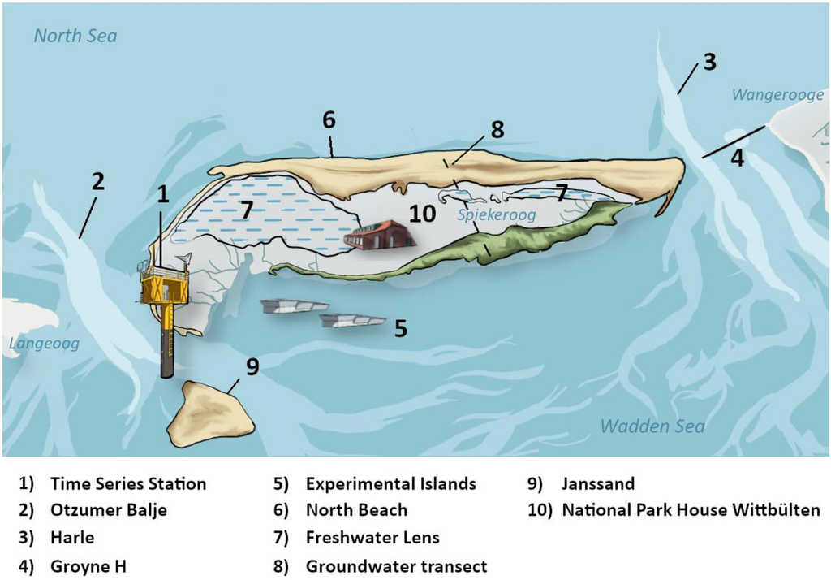

[figure not shown]

Below is the map of the temperature sensors in Spiekeroog used for this analysis (Time Series Station and Experimental islands).

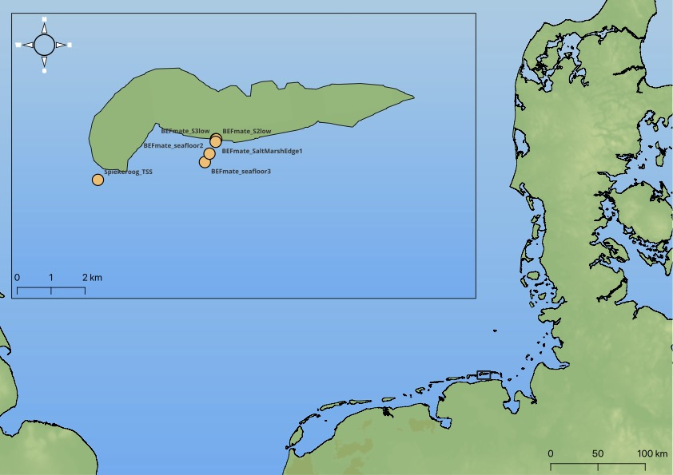

There are six sensors recording temperature data every ten minutes. For modeling purposes, we have aggregated the temperature data into weekly averages. Despite occasional missing data, the time series are generally continuous, allowing for reliable weekly averaging without introducing significant bias. The **Sediment_LSM** sample was taken from the lower saltmarsh zone at plot 3, at an elevation of 1.7 m and a depth of 5 cm, located off Spiekeroog in the German Bight, North Sea. The **Sediment_MUD_RCM** sample was collected from the sea floor of the back-barrier tidal flat in a mudflat, at an elevation of 0.7 m and a depth of 5 cm, also off Spiekeroog. Similarly, the **Sediment_MUD_RBR** sample, collected from the sea floor of the back-barrier tidal flat in a mudflat, had an elevation of 0.8 m and a depth of 5 cm, situated near Spiekeroog. The **Sediment_SME_RBR** sample was gathered from the salt marsh edge of the back-barrier tidal flat, at an elevation of 1.0 m and a depth of 5 cm, off Spiekeroog. The **Air** sample was taken from the Time Series Station (TSS) at Spiekeroog, with an elevation of 12 m, while the **Water_4_4BSF** sample was collected at the same station at a depth of 4 m below the sea floor (bsf), both located in the German Bight, North Sea.

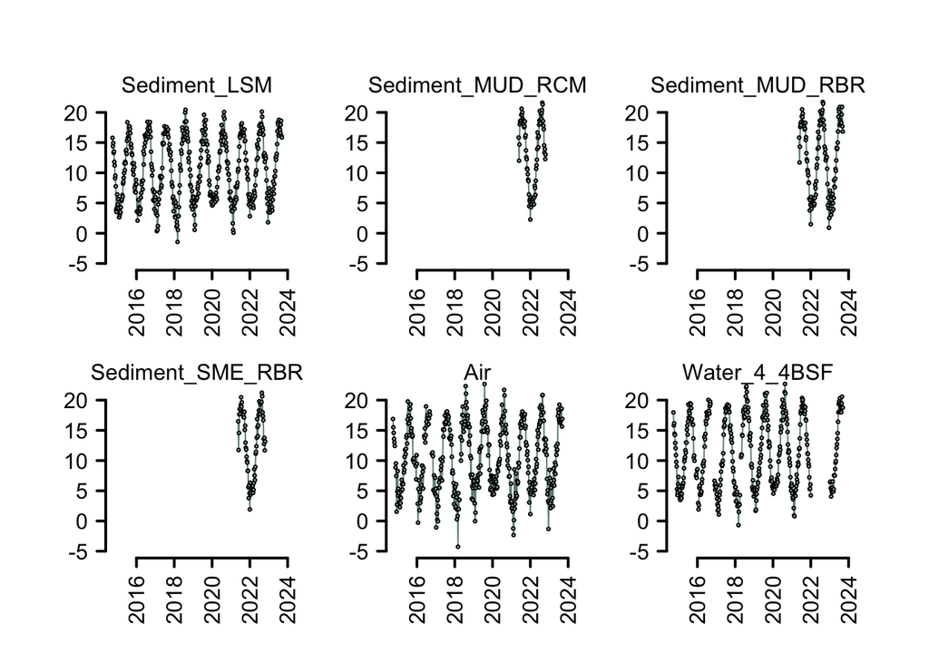

# Relationship between measured temperatures

We compared all sensors to each other using a Generalised Least Squares (GLS) model which account for temporal autocorrelation in the data (autoregressive correlation structure of order 1 - `corAR1`). The model is evaluated using Nagelkerke’s pseudo R-squared. An estimate of 1 indicates a perfect alignment between the two temperatures, meaning that a 1-degree increase in one temperature corresponds exactly to a 1-degree increase in the other.

## Table of Estimates and R-squared

The table below summarizes the estimates and Nagelkerke pseudo R-squared values for each unique pairwise combination of variables.

GLS Model Estimates and Nagelkerke Pseudo R-Squared for Unique Pairwise Combinations

| predictor | response | estimate | R2 |
| --- | --- | --- | --- |
| Air | Sediment_LSM | 0.5750387 | 0.774706 |
| Air | Sediment_MUD_RBR | 0.7174494 | 0.733585 |
| Air | Sediment_MUD_RCM | 0.6686781 | 0.644427 |
| Air | Sediment_SME_RBR | 0.7670292 | 0.675620 |
| Air | Water_4_4BSF | 0.4617290 | 0.570595 |
| Sediment_LSM | Sediment_MUD_RBR | 1.1128955 | 0.909280 |
| Sediment_LSM | Sediment_MUD_RCM | 1.0578490 | 0.851031 |
| Sediment_LSM | Sediment_SME_RBR | 1.1260268 | 0.829583 |
| Sediment_LSM | Water_4_4BSF | 1.0813436 | 0.850233 |
| Sediment_MUD_RBR | Sediment_MUD_RCM | 0.9359163 | 1.011720 |
| Sediment_MUD_RBR | Sediment_SME_RBR | 0.9707097 | 0.999032 |
| Sediment_MUD_RBR | Water_4_4BSF | 0.5659126 | 1.000000 |
| Sediment_MUD_RCM | Sediment_SME_RBR | 0.9718435 | 0.981908 |
| Sediment_MUD_RCM | Water_4_4BSF | 0.6283468 | 1.000000 |
| Sediment_SME_RBR | Water_4_4BSF | 0.5047000 | 1.000000 |

## Visualizing the Estimates

The heatmap represents the estimates (colour) and the pseudo R-squared are indicated.

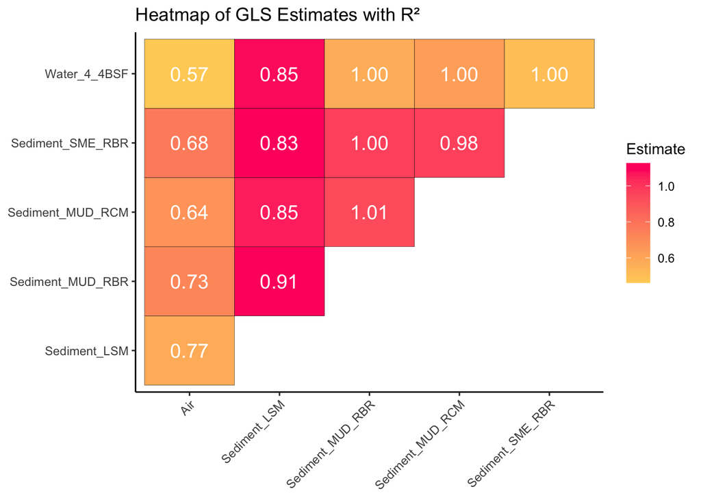

# Conclusion

Although we observed a strong overall relationship between air and sediment temperatures, the estimate for water temperature is the lowest among the observed estimates (0.46). This suggests that **we should be using estimated water temperatures**, based on the relationships observed in this dataset, when studying the impact of temperature on community tropicalization.